# Modeling and prediction for movies

## Setup

### Load packages

```r
library(ggplot2)
library(dplyr)
library(statsr)
```

### Load data

```r
load("movies.Rdata")
```

## Part 1: Data

I will be using the dataset that includes information about the 651 randomly sampled movies produced and released before 2016, taken from Rotten Tomatoes and IMDB. The data was taken from the sources via Rotten Tomatoes and IMDB APIs. The data consists of numerica, categorical and continous variables, including variables (such as URLs) which can be easily dropped and are not significant for our feature selection.

## Part 2: Research question

How to predict the ‘imdb_rating’ using a set of independent variables from Movies.Rdata dataset?

## Part 3: Exploratory data analysis

```r
movies_consider <- select(movies, -actor2, -actor3, -actor4, -actor5)
movies_consider <-select(movies_consider, -thtr_rel_month, -thtr_rel_day, -dvd_rel_year, -dvd_rel_month, -dvd_rel_day, -best_pic_nom, - best_dir_win)
movies_consider <-select(movies_consider, -imdb_url, -rt_url, -best_actor_win, -best_actress_win, -imdb_num_votes, -thtr_rel_year)
movies_consider <-select(movies_consider, -mpaa_rating, -studio)
```

Second, remember, that our predictors have to be independent, therefore, I vary about if the “critics_score”, “critics_rating”, “audience_score”, “audience_score”. For that reason we have to build a correlation matrix, to check the correlation coefficient. I need to convert all the variables to dataframe to manipulate them. - I build a unuqie dataframe, that will tackle this problem. Note, that to plot the correlation coefficient we have to conver the dataframe to matrix.

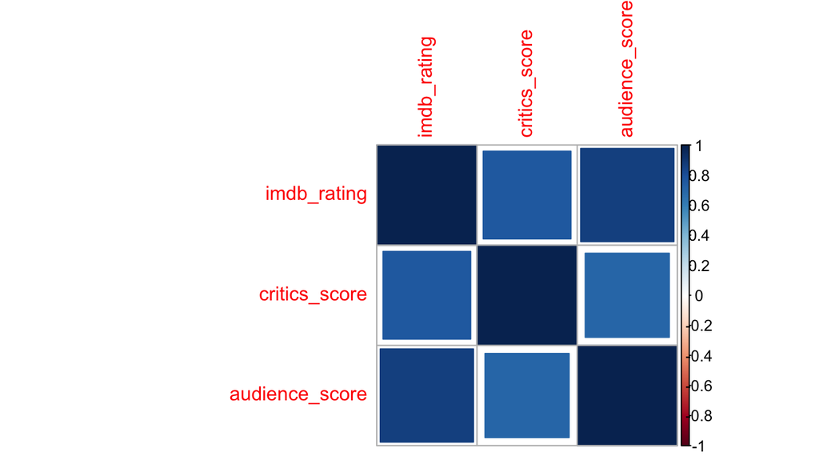

```r
library(corrplot)
dataset_1 <- select(movies_consider, imdb_rating, critics_score, audience_score)
dataset_1 <- as.matrix(dataset_1)
M <- cor(dataset_1)
corrplot(M, method = "square")
```

As we can observe, three of these variables are highly correlated, so we will stay with “audience_score” and drop the “critics score”.

```r
movies_consider <-select(movies_consider, -critics_score, -critics_rating, -audience_rating)
```

There are two more variables bothering me - “title_type” and “runtime”. In essense, title_type has not only something to do with the place where it can be seen, but also with the length of the movie. Hence we need to test for independence. As I am dealing with one categorical variable and one numerical variable, I will use one-way ANOVA.

```r
anova <- select(movies_consider, title_type, runtime)
levels(anova$title_type)
```

```
## [1] "Documentary"  "Feature Film" "TV Movie"
```

```r
anova$title_type <- ordered(anova$title_type, levels = c("Documentary", "Feature Film", "TV Movie"))
group_by(anova, anova$title_type) %>%
   summarise(
     count = n(),
     mean = mean(runtime, na.rm = TRUE),
    sd = sd(runtime, na.rm = TRUE))
```

```
## # A tibble: 3 x 4
##   `anova$title_type` count  mean    sd
##   <ord>              <int> <dbl> <dbl>
## 1 Documentary           55  97.7  32.3
## 2 Feature Film         591 107.   17.7
## 3 TV Movie               5 102.   12.3
```

I have ordered the three levels of my categorical variables and counted the summary statistics. As it can be seen from the result, there are more Feature Films in our dataset with the higher length of each movie. The shortest are the Documentary movies. Both of facts can be interpreted as bias as we use mean for summary statistics. Let’s visualize our results and check for outliers:

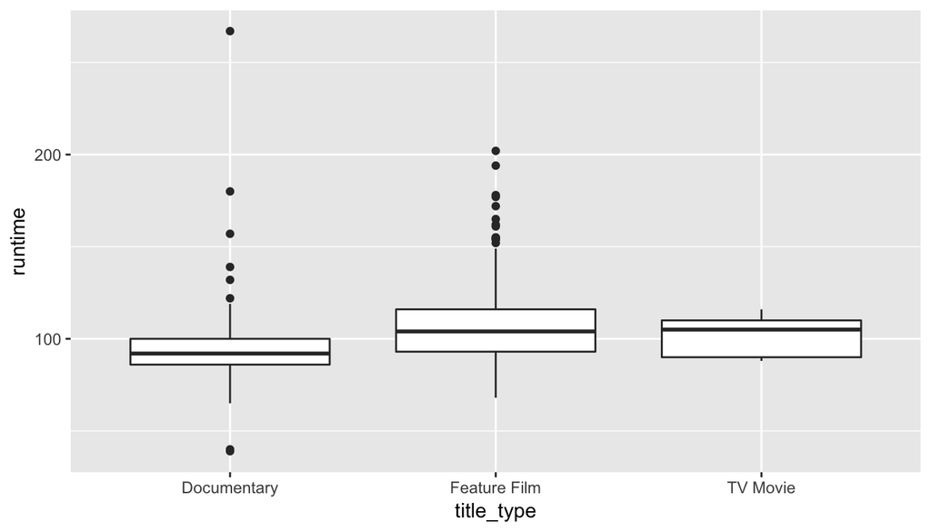

```r
ggplot(anova, aes(x=title_type, y=runtime)) +      geom_boxplot()
```

The graph shows us that there are number of outliers that influence the mean of two levels - “Documentary” and “Feature Film”.

```r
# Compute the analysis of variance
 res.aov <- aov(runtime ~ title_type, data = anova)
 # Summary of the analysis
 summary(res.aov)
```

```
##              Df Sum Sq Mean Sq F value  Pr(>F)
## title_type    2   3960  1979.8   5.306 0.00518 **
## Residuals   647 241434   373.2
## ---
## Signif. codes:  0 '***' 0.001 '**' 0.01 '*' 0.05 '.' 0.1 ' ' 1
## 1 observation deleted due to missingness
```

We typically test at a significance level of = 0.05 and out p-value is less than 0.05, the null hypothesis is rejected. That is, the data provide convincing evidence that there is some dependence between ‘title_type’ and ‘runtime’. Hence we will drop “runtime” and stya with “title_type”. As far as I am concerned, the “title_type” is much more representative, as it influences if people prefer going to the cinema or staying at home. We can also build a correlation matrix, if we want to examine it in minute detail.

```r
movies_consider <-select(movies_consider, -runtime)
```

## Part 4: Modeling

So, here we ago, we ended up with 7 predictors, 1 dependent variable and 1 index (title). The reasons are listed above and I assume, that after detailed EDA we ended up with independent variables to predict imdb_rating. I am not certain if my dataset does not contain missing values, that can influence the prediction power of our model, therefore I have to drop them first.

```r
na_vec <- which(!complete.cases(movies_consider))
finaldt_no_na <- movies_consider[-na_vec,]
```

Model selection method I will choose the backward elimination with adjust R^2, as I have categorical variables with loads of levels that can be significant, but don’t influence the predictive power of the model that much.

```r
model_full = lm(imdb_rating ~ title_type + genre + audience_score + best_pic_win + top200_box + director + actor1, data = finaldt_no_na)
summary(model_full)$adj.r.squared
```

```
## [1] 0.7778587
```

```r
model_full_actor1 = lm(imdb_rating ~ title_type + genre + audience_score + best_pic_win + top200_box + director, data = finaldt_no_na)
summary(model_full_actor1)$adj.r.squared
```

```
## [1] 0.9045345
```

I won’t show every lm function in my process, as it will take too much place. For the first step, I ended up with dropping the actor1, as it has the highest Adjusted R^2 of 0.9 Step 2 includes the same process, dropping one variable at a time. Let’s see what the future holds for us (The code provides only the snippet with the highest adjusted R^2, all the computations were made in the background )

```r
model_genre = lm(imdb_rating ~ title_type + director + top200_box + best_pic_win + audience_score, data = finaldt_no_na)
summary(model_genre)$adj.r.squared
```

```
## [1] 0.9076678
```

I drop genre, as our adjusted R^2 has moved from 0.9 to 0.91.

```r
model_genre_top200_box = lm(imdb_rating ~ title_type + director + best_pic_win + audience_score, data = finaldt_no_na)
summary(model_genre_top200_box)$adj.r.squared
```

```
## [1] 0.9083838
```

So here we go, it seems that these four variables have the most powerful impact on imdb_rating score. In essence, it means that Rotten Tomatoes audience has a greatful influence on the audience of imdb_rating (if it differs). People tend to score the movie higher depending whether the type of the movie (also remember about the genre), if the movie has won the Oscar and director.

Model Diagnostics Linear Relationship between numerical x and y. For numerical variable we consider “audience score”.

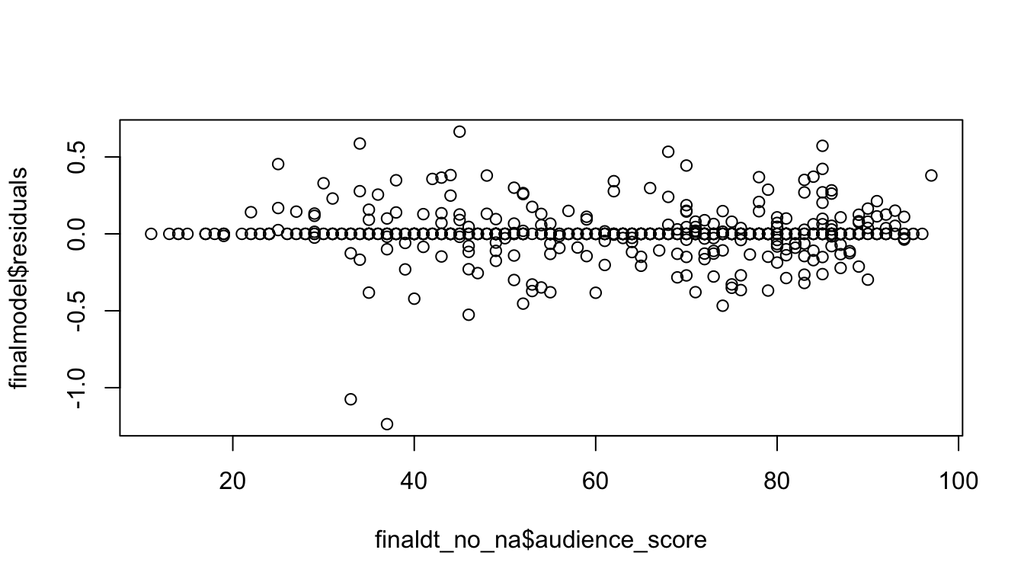

```r
finalmodel = lm(imdb_rating ~ title_type + director + best_pic_win + audience_score, data = finaldt_no_na)
plot(finalmodel$residuals ~ finaldt_no_na$audience_score)
```

We can see from the above plot that our linear relationship condition is not met.

Nearly Normal Residuals with mean 0

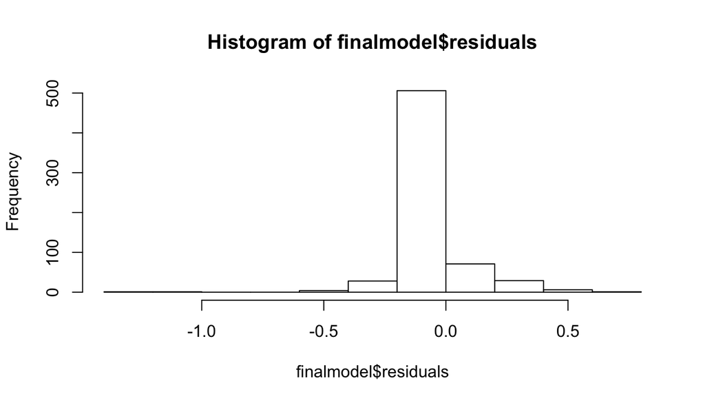

```r
hist(finalmodel$residuals)
```

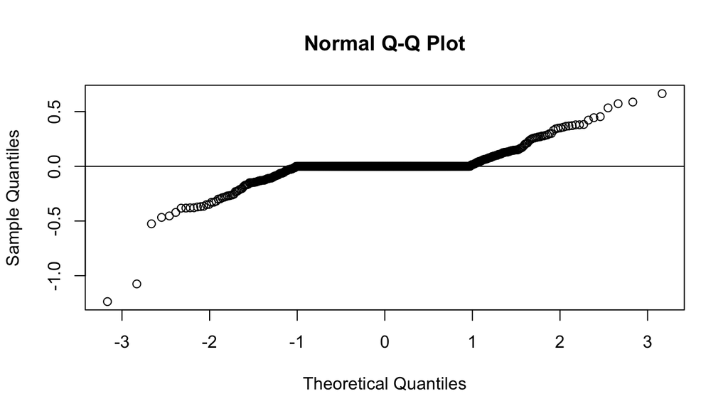

```r
qqnorm(finalmodel$residuals)
qqline(finalmodel$residuals)
```

Here is an example of a bad-looking normal quantile plot ( we see a S-shaped pattern).

Constant variability of residuals

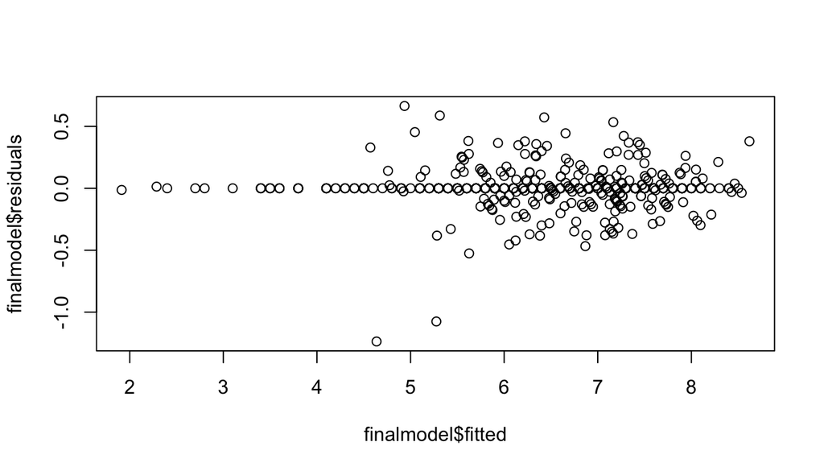

```r
plot(finalmodel$residuals ~ finalmodel$fitted)
```

Here we see that it randomly scattered near 0 and we can’t see another pattern (such as fan-shaped or whatsoever).

Independent residuals

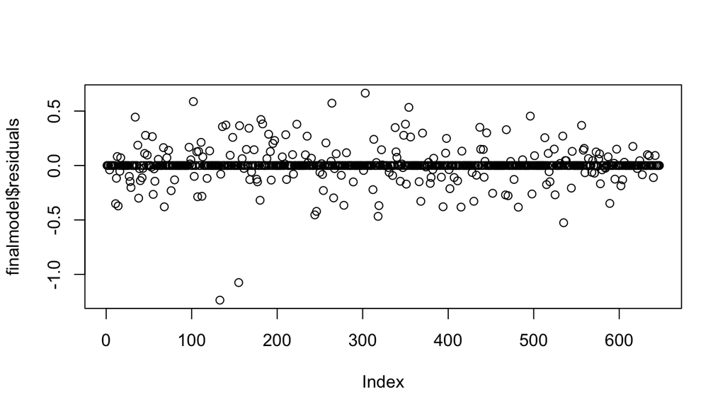

```r
plot(finalmodel$residuals)
```

From my dianostics, it’s clear that it would be better if I has taken another numerical variable - e.g. “audience_rating”. Then the linearity condition would be met. We see those residuals plotted on the 0 that are categotical. If I consider the numerical variables, the conditions will be met. For instance, we can use the algorithm - this is a commonly applied way to get rid of some of this issues, basically because it removes the influence of variables being measured in different units (i.e. something measured in 0.1 steps, something else in 1,000s …).

## Part 5: Prediction

For making a prediction, I use the film Filly Brown. Source: https://www.imdb.com/title/tt1869425/?ref_=fn_al_tt_1

```r
title_type <- "Feature Film"
director <- "Michael D. Olmos"
audience_score <- 73
best_pic_win <- "no"
imdb_rating <-5.5
FillyBrown <- data.frame (title_type, director, best_pic_win, audience_score, imdb_rating)
myPrediction <- round(predict(finalmodel, FillyBrown), digits = 0)
c(myPrediction, FillyBrown$imdb_rating)
```

```
##   1
## 6.0 5.5
```

```r
ConfidenceInterval <- predict(finalmodel, FillyBrown, interval="confidence")
ConfidenceInterval
```

```
##   fit      lwr      upr
## 1 5.5 4.848864 6.151136
```

We are 95% confident that, all else being equal, the predicted imdb_rating for the movie ‘Filly Brown’ will be between 4.85 and 6.15 on average.

## Part 6: Conclusion

As we can see from the calculations above, we have set the regression model for predicting imdb_rating. As the test dataframe contains more “Feature Film” , this model is more reliable for this title type. As we haven’t taken the genre into account, this make our model more universal. However, as we have included categorical variables into our dataset, we have to do normalization of these variables into the future to satisfy all the MLR diagnostics. The only thing that makes this model weak is if we try to predict the movie with the unknown director (which is not given in your data sample) - this makes our model less representative.